# MG205: Econometrics Theory and Applications

Empirical Exercise 8: Death Penalty

José Ignacio González Rojas

j.i.gonzalez-rojas@lse.ac.uk

London School of Economics and Political Science

## Today: Identifying Fragility in the Death Penalty Evidence

#### What We Learned in Lobbyists?

- **Panel FE** removes time-invariant heterogeneity
- **Politician exits** provide within-person variation in connections
- **Event study** validates parallel trends assumption

#### Today’s Agenda

1. DiD approach to death penalty deterrence
2. Why clustering and outliers can flip conclusions
3. IV approach and its two failure modes
4. Exclusion restriction test

## Rational Criminals Should Respond to Deterrence — but Brutalisation Cuts the Other Way

### Becker (1968)

#### Deterrence Hypothesis

- **Rational-choice model of crime:** criminals weigh expected benefits against expected costs
- Death penalty is the maximum possible sanction
- **Prediction:** more executions → fewer homicides

#### Brutalisation Hypothesis

- State violence legitimises lethal force
- Executions may normalise killing in society
- **Prediction:** more executions → more homicides

Both predictions are internally consistent.

### Descriptive Evidence

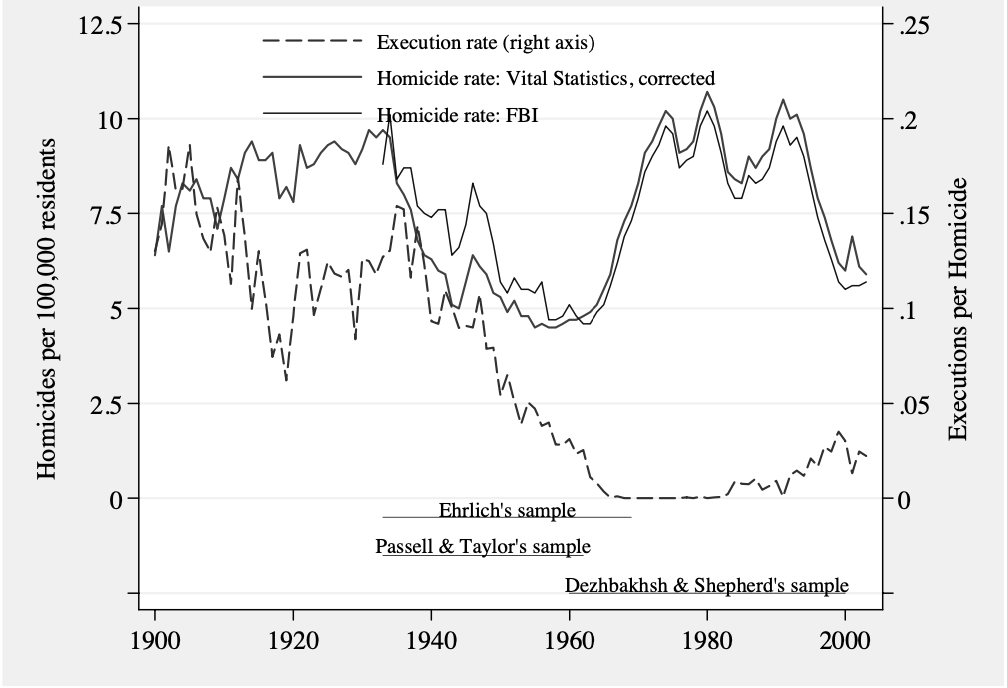

# The Judicial Experiment

## Supreme Court Decisions Created Staggered State-Level Variation in Death Penalty Status

### Furman (1972) and Gregg (1976)

- **Furman v. Georgia (1972):** Court found arbitrary application unconstitutional — effectively suspended all executions nationwide.
- **Gregg v. Georgia (1976):** Court permitted reinstatement if states rewrote statutes with guided discretion.
- **Staggered reinstatement:** states reintroduced the death penalty at different times between 1976 and 1995 — variation in treatment timing.
- **Comparison group:** states that never reinstated provide an untreated control.

Treatment was legally driven, not chosen on the basis of current crime levels.

## States With and Without the Death Penalty Follow Similar Pre-Period Trends

### Difference-in-Differences

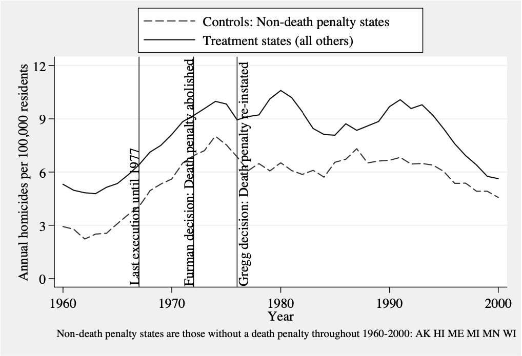

## Clustering Standard Errors Erases the Death Penalty Effect

### Dezhbakhsh & Shepherd (2006)

$$y_{st} = \alpha_{s} + \gamma_{t} + \beta \cdot \mathbb{1}[\text{Legal death penalty}_{st}] + e_{st}$$

where $y_{st}$ = homicide rate per 100,000 in state $s$, year $t$

|  | (1) | (2) | (3) |
| --- | --- | --- | --- |
| **Legal Death Penalty** | -0.955*** (0.205) | -0.955* (0.565) | -0.472 (0.727) |
| State FE | Yes | Yes | Yes |
| Year FE | No | No | Yes |
| Decade FE | Yes | Yes | No |
| Standard errors | Robust | Clustered: State | Clustered: State |

Note: Dependent variable is homicide rate per 100,000 population. SE in parentheses. *** p<0.01, * p<0.10.

## Small Specification Changes Reverse the Death Penalty Effect

**2 — Year FE vs. decade FE:** decade dummies too coarse for national crime trends (crack epidemic, policing). Year FE halve the coefficient → insignificant.

**3 — Removing Texas:** one-third of all US executions. Drop one state → the result disappears.

A finding that relies on one state and one SE choice is not robust evidence.

## Fixed Effects Cannot Remove Threats That Change Over Time

### Remaining Endogeneity

- **Reverse causality:** states may adopt or expand the death penalty in response to rising homicide rates — crime drives policy, not just the other way around.
- **Policy bundling:** states that reinstate the death penalty often simultaneously increase policing or change sentencing — the indicator picks up all of these.
- **Time-varying omitted variables:** changing attitudes toward crime, drug epidemics, and policing strategies correlate with both death penalty status and homicide.
- **Measurement gap:** legal status ≠ actual execution probability; most death sentences are never carried out.

State and year FE absorb time-invariant differences but not these time-varying threats.

# The Instrumental Variables Approach

## Instrument Execution Probability with Republican Vote Share

### Dezhbakhsh et al. (2003)

#### Instruments

- Republican Vote Share (RVS) in the most recent presidential election
- Judicial expenditure
- Police expenditure
- Prison rate per capita
- **Logic:** Republican-leaning counties
  - Pro-death-penalty prosecutors
  - Higher arrest, sentencing, and execution probabilities.

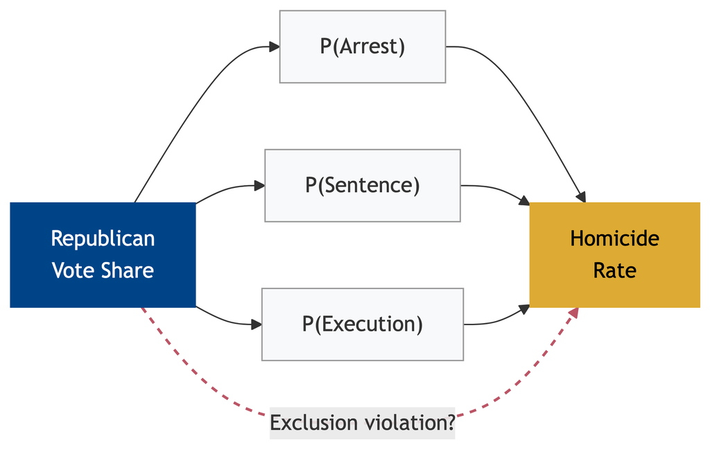

- **Relevance:** Instruments must predict the three probabilities ($F > 10$)
- **Exclusion:** Instruments must affect homicide *only through* the death penalty chain

## Weak Instruments Undermine the IV Estimates

### Dezhbakhsh et al. (2003)

[output not shown]

Note: SE in parentheses. *** p<0.01, ** p<0.05, * p<0.10. Weak instruments: F < 10. Orange: F < 2 (catastrophic). RVS = Republican Vote Share. EYD = Election Year Dummy.

## Republican Vote Share Predicts Robbery Rates

### Donohue & Wolfers (2005)

|  | Assault rate | Assault rate | Robbery rate | Robbery rate |
| --- | --- | --- | --- | --- |
| Police expenditure | -9.29×10<sup>-6</sup> (1.89×10<sup>-5</sup>) | -1.04×10<sup>-5</sup> (1.79×10<sup>-5</sup>) | -4.1×10<sup>-5</sup> (4.22×10<sup>-5</sup>) | -4.21×10<sup>-5</sup> (4.28×10<sup>-5</sup>) |
| Judicial expenditure | 8.58×10<sup>-6</sup> (2.97×10<sup>-5</sup>) | 1.52×10<sup>-5</sup> (2.54×10<sup>-5</sup>) | 3.48×10<sup>-5</sup> (6.7×10<sup>-5</sup>) | 4.16×10<sup>-5</sup> (6.77×10<sup>-5</sup>) |
| **Prisoners/Population** | 0.00168 (0.00121) | 0.00155 (0.00123) | **0.00325**** (7.84×10<sup>-4</sup>) | **0.00310**** (7.14×10<sup>-4</sup>) |
| **Republican Vote Share** | — | 1.259 (1.247) | — | **1.300*** (0.655) |

Note: Dependent variables are assault and robbery rates per 100,000 population. County and year fixed effects. SE clustered at state level in parentheses.  
*** p<0.01, ** p<0.05, * p<0.10. If Republican Vote Share predicts non-murder crime, the exclusion restriction is violated.

If the instrument predicts other crime rates, it cannot credibly isolate the death penalty effect.

# Summary

## Three Lessons from the Death Penalty Debate

### Summary

1. **Cluster at the right level — it changes conclusions**  
   State-level laws create within-state correlation; clustering at the state dissolves the deterrence finding
2. **Check whether one observation drives results**  
   Texas accounts for one-third of US executions; results should survive the removal of any single state
3. **IV is only as good as its instrument**  
   Weak first stages ($F < 10$) and exclusion restriction violations are not caveats — they invalidate IV

# References

## References

Becker, G. S. (1968). Crime and Punishment: An Economic Approach. *Journal of Political Economy*, *76*(2), 169–217.

Dezhbakhsh, H., Rubin, P. H., & Shepherd, J. M. (2003). Does Capital Punishment Have a Deterrent Effect? New Evidence from Postmoratorium Panel Data. *American Law and Economics Review*, *5*(2), 344–376. https://doi.org/10.1093/aler/ahg021

Dezhbakhsh, H., & Shepherd, J. M. (2006). The Deterrent Effect of Capital Punishment: Evidence from a “Judicial Experiment.” *Economic Inquiry*, *44*(3), 512–535. https://doi.org/10.1093/ei/cbj032

Donohue, J. J., & Wolfers, J. (2005). Uses and Abuses of Empirical Evidence in the Death Penalty Debate. *Stanford Law Review*, *58*(3), 791–845.